# Лабораторная работа №2

Первичная настройка Git

Нечаева К.А.

Российский университет дружбы народов, Москва, Россия

01 марта 2024

# Информация

## Докладчик

- Нечаева Кира Андреевна
- студентка
- Российский университет дружбы народов
- 1132236031@pfur.ru

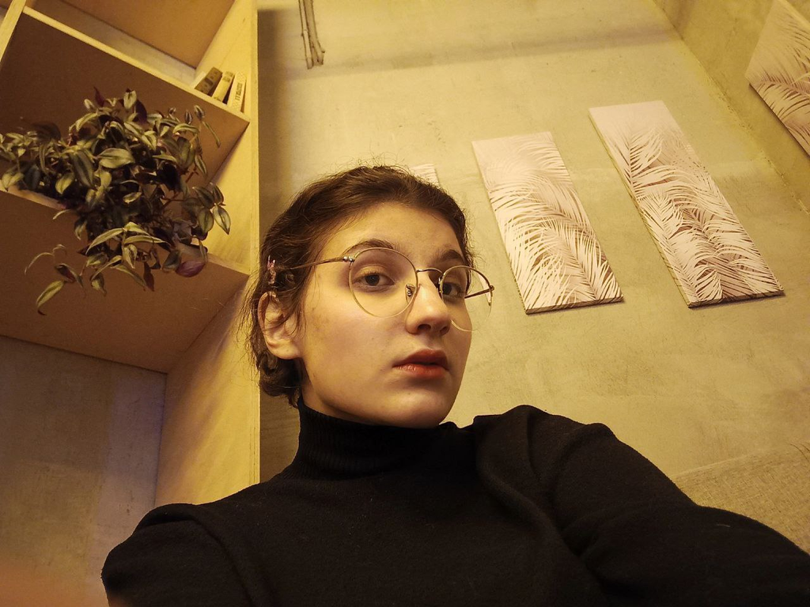

# Вводная часть

## Актуальность

- Важно уметь работать с системой Git
- Необходимо уметь создать репозиторий для дальнейшей работы
- Желательно уметь клонировать данные с компьютера на сайт автоматически

## Объект и предмет исследования

- Система Git
- Работа на Github

## Цели и задачи

- Изучение идеологии и применение средств контроля версий
- Приобрести практические навыки по работе с системой git.

## Материалы и методы

- Система Git
- Консоль (терминал) Linux

# Ход лабораторной работы

## 1. Установка git

Поскольку у меня уже установлен Github, я могу пропустить этот шаг, однако я покажу, что Git у меня есть.

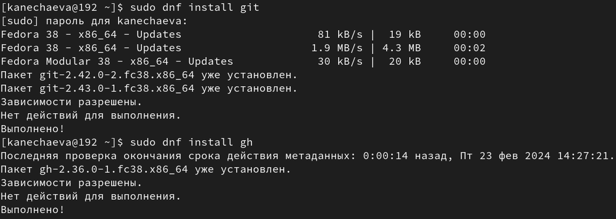

## 2. Базовая настройка git

Сначала необходимо сделать предварительную конфигурацию git. Настраиваю utf-8 в выводе сообщений git для верного отображения символов. Задаю имя начальной ветки “master”. Задаю параметры autocrlf и safecrlf.

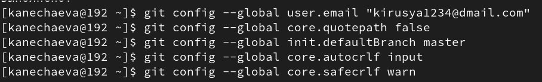

## 3. Создание SSH ключа

Для последующей идентификации пользователя на сервере репозиториев генерирую пару SSH ключей: по алгоритму rsa и по алгоритму ed25519.

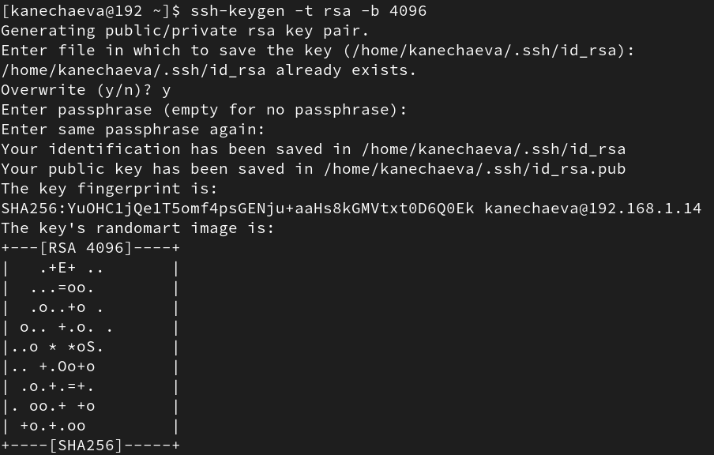

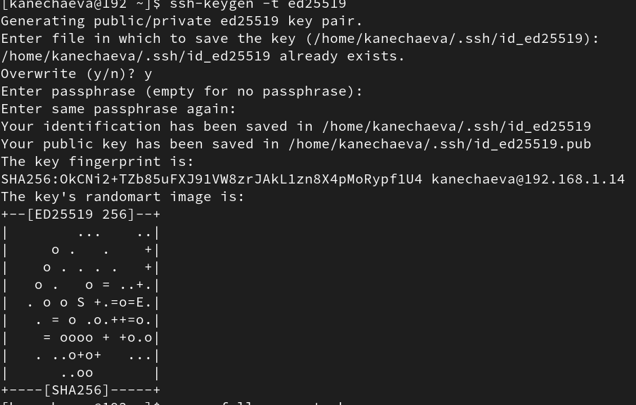

## 4. Создание GPG ключа

Затем генерирую gpg ключ. Из предложенных опций выбираю тип RSA and RSA, размер 4096 и безвременный срок действия. Затем ввожу некоторую личную информацию и придумываю пароль.

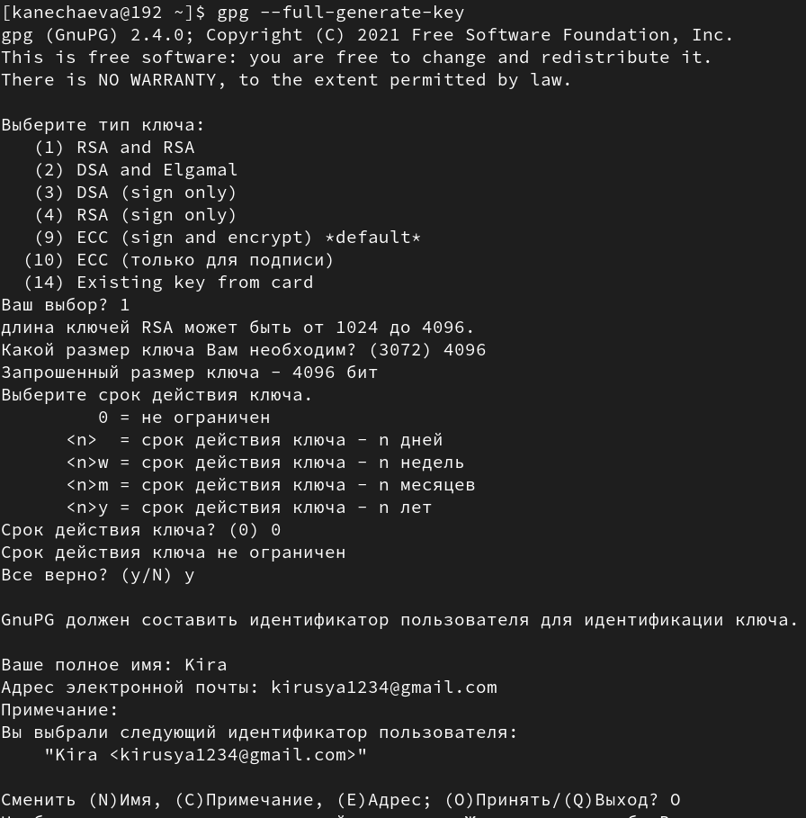

Теперь я вывожу список ключей и копирую отпечаток приватного ключа в буфер обмена.

Захожу на сайт GitHub. Выбираю в меню “Настройки”, затем “SSH and GPG keys”. Нажимаю кнопку «New GPG key». Вставляю скопированный ключ в поле «Key». Нажимаю «Add GPG-key», чтобы завершить добавление ключа.

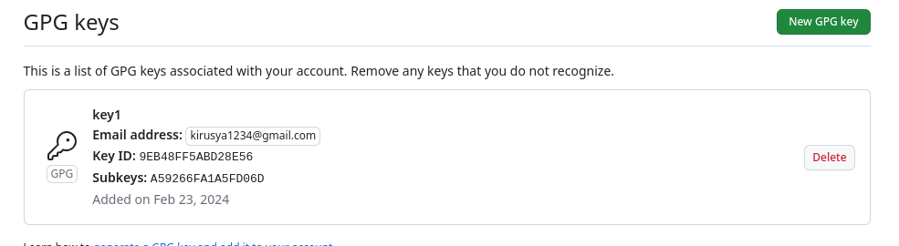

## 5. Настройка gh

Используя введёный email, указываю Git применять его при подписи коммитов. Теперь необходимо авторизоваться. Утилита задаст несколько наводящих вопросов, после чего я авторизовываюсь через браузер.

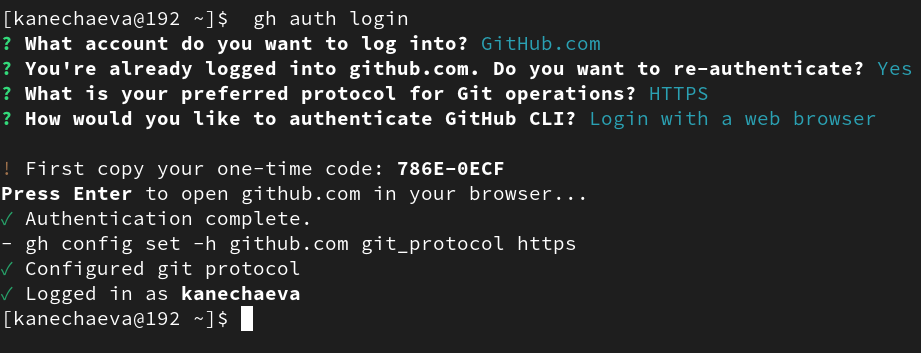

## 6. Создание рабочего пространства на основе шаблона

Репозиторий на основе шаблона создаю через web-интерфейс github. Перехожу на станицу репозитория с шаблоном курса https://github.com/yamadharma/course-directory-student-template. Далее выбераю Use this template.

## 7. Сознание репозитория курса на основе шаблона

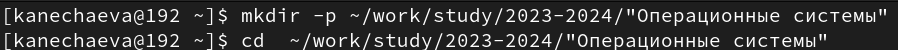

[figure not shown]

## 8. Настройка каталога курса

Перехожу в каталог курса, удалияю лишние файлы и создаю необходимые каталоги. После чего отправляю файлы на сервер.

[figure not shown]

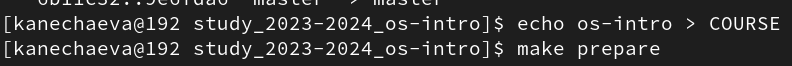

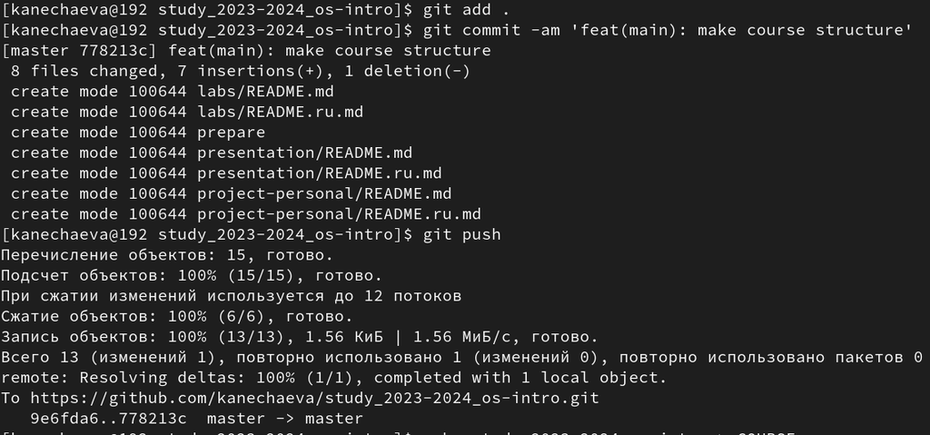

# Результаты

- Я изучила идеологию и применение средств контроля версий.
- Я приобрела практические навыки по работе с системой git.

# Список литературы

## Код для формата `pdf`

```yaml
slide_level: 2
aspectratio: 169
section-titles: true
theme: metropolis
```

## Код для формата `html`

```
REVEALJS_THEME = beige
```